# Receiving news - Bayesian Mixed Linear Models

```
By Valentin Guigon
July 2023
```

# Models

First, we computed a non-informative beta response model to model randomness (Jeffrey priors, α = 0.5, β = 0.5):

```
## Success | trials(1) ~ (1 | Subject)
```

Then, we computed a subject random-effect model:

```
## Success | trials(1) ~ 1 + (1 | Subject)
```

We computed a cognitive reflection model:

```
## Success | trials(1) ~ 1 + Estimation_RT + (1 | Subject)
```

We computed the veracity judgment model:

```
## Success | trials(1) ~ 1 + Judgment + (1 | Subject)
```

We computed the model corresponding to our hypothesis, the news content imprecision model:

```
## Success | trials(1) ~ 1 + Veracity:Imprecision + (1 | Subject)
```

We computed the model corresponding to our hypothesis, the news content Polarization model:

```
## Success | trials(1) ~ 1 + Veracity:Polarization + (1 | Subject)
```

We computed the model corresponding to our hypothesis, the news content imprecision & Polarization model:

```
## Success | trials(1) ~ 1 + Veracity:Imprecision + Veracity:Polarization + (1 | Subject)
```

Finally, we computed the model of stickiness of prior knowledge:

```
## Success | trials(1) ~ 1 + Theme:orgaBest + (1 | Subject)
```

# Models comparison

The Bayesian Mixed Linear Model that explains best participants’ performances is the model of news content imprecision & Polarization with both variables interacting with news veracity.

```
##                  model  elpd_diff   se_diff elpd_waic se_elpd_waic    p_waic
## 1  mSuccessImprecPolar    0.00000  0.000000 -8445.343    16.790773 10.452947
## 2 mSuccessPolarization  -30.23763  8.055327 -8475.581    14.925430  8.088051
## 3  mSuccessImprecision -105.47625 14.459185 -8550.820     8.667215  8.586625
## 4 mSuccessOrganization -126.70348 17.009913 -8572.047     5.812943  9.991130
## 5           mSuccessRT -132.18791 16.738321 -8577.531     4.993077  7.355160
## 6      mSuccessSubject -134.49672 16.391543 -8579.840     3.499284  6.247871
## 7       mSuccessRandom -134.53127 16.393805 -8579.875     3.347035  6.305190
## 8     mSuccessJudgment -134.98015 16.364142 -8580.323     3.629070  7.301251
##     se_p_waic     waic   se_waic weight
## 1 0.044407700 16890.69 33.581547      1
## 2 0.035254227 16951.16 29.850859      0
## 3 0.027128591 17101.64 17.334429      0
## 4 0.023853874 17144.09 11.625886      0
## 5 0.736705304 17155.06  9.986154      0
## 6 0.004263497 17159.68  6.998568      0
## 7 0.004166796 17159.75  6.694070      0
## 8 0.005693666 17160.65  7.258140      0
```

```
##  Family: binomial
##   Links: mu = logit
## Formula: Success | trials(1) ~ 1 + Veracity:Imprecision + Veracity:Polarization + (1 | Subject)
##    Data: dRec (Number of observations: 12384)
##   Draws: 4 chains, each with iter = 4000; warmup = 1500; thin = 1;
##          total post-warmup draws = 10000
##
## Group-Level Effects:
## ~Subject (Number of levels: 258)
##               Estimate Est.Error l-95% CI u-95% CI Rhat Bulk_ESS Tail_ESS
## sd(Intercept)     0.03      0.03     0.00     0.09 1.00     3895     4884
##
## Population-Level Effects:
##                            Estimate Est.Error l-95% CI u-95% CI Rhat Bulk_ESS
## Intercept                      0.10      0.02     0.06     0.13 1.00    18444
## VeracityTrue:Imprecision      -0.06      0.03    -0.11    -0.01 1.00    18045
## VeracityFalse:Imprecision      0.20      0.03     0.15     0.25 1.00    17164
## VeracityTrue:Polarization     -0.18      0.03    -0.23    -0.12 1.00    18717
## VeracityFalse:Polarization     0.34      0.03     0.28     0.39 1.00    18236
##                            Tail_ESS
## Intercept                      7083
## VeracityTrue:Imprecision       6711
## VeracityFalse:Imprecision      5658
## VeracityTrue:Polarization      6855
## VeracityFalse:Polarization     6689
##
## Draws were sampled using sampling(NUTS). For each parameter, Bulk_ESS
## and Tail_ESS are effective sample size measures, and Rhat is the potential
## scale reduction factor on split chains (at convergence, Rhat = 1).
```

# Winning model: Posterior estimated effects

We ran a second version of the model, with controls such as the NHST imprecision model:

```
##  Family: binomial
##   Links: mu = logit
## Formula: Success | trials(1) ~ 1 + Veracity * Imprecision + Veracity * Polarization + Confidence + Veracity * Theme + (1 | Subject)
##    Data: dRec (Number of observations: 12384)
##   Draws: 4 chains, each with iter = 4000; warmup = 1500; thin = 1;
##          total post-warmup draws = 10000
##
## Group-Level Effects:
## ~Subject (Number of levels: 258)
##               Estimate Est.Error l-95% CI u-95% CI Rhat Bulk_ESS Tail_ESS
## sd(Intercept)     0.04      0.03     0.00     0.11 1.00     2846     4042
##
## Population-Level Effects:
##                                  Estimate Est.Error l-95% CI u-95% CI Rhat
## Intercept                            0.62      0.06     0.49     0.74 1.00
## VeracityFalse                       -1.14      0.07    -1.28    -1.00 1.00
## Imprecision                         -0.13      0.03    -0.19    -0.08 1.00
## Polarization                        -0.16      0.03    -0.22    -0.10 1.00
## Confidence                           0.00      0.00     0.00     0.00 1.00
## ThemeDemocracy                      -0.39      0.07    -0.53    -0.24 1.00
## ThemeSocialJustice                   0.04      0.07    -0.10     0.17 1.00
## VeracityFalse:Imprecision            0.28      0.04     0.20     0.36 1.00
## VeracityFalse:Polarization           0.48      0.04     0.40     0.57 1.00
## VeracityFalse:ThemeDemocracy         0.42      0.10     0.22     0.62 1.00
## VeracityFalse:ThemeSocialJustice    -0.10      0.10    -0.29     0.10 1.00
##                                  Bulk_ESS Tail_ESS
## Intercept                            5970     7968
## VeracityFalse                        4766     6571
## Imprecision                          9447     7842
## Polarization                         6428     7331
## Confidence                          10981     7487
## ThemeDemocracy                       4924     6857
## ThemeSocialJustice                   5297     7017
## VeracityFalse:Imprecision            9140     8102
## VeracityFalse:Polarization           6506     7508
## VeracityFalse:ThemeDemocracy         4908     6525
## VeracityFalse:ThemeSocialJustice     5113     6631
##
## Draws were sampled using sampling(NUTS). For each parameter, Bulk_ESS
## and Tail_ESS are effective sample size measures, and Rhat is the potential
## scale reduction factor on split chains (at convergence, Rhat = 1).
```

The estimated effects clearly show that prediction success was more likely for true news when their content imprecision was at its minimum rather than maximum. It was more likely for false news when imprecision was at its maximum rather than minimum:

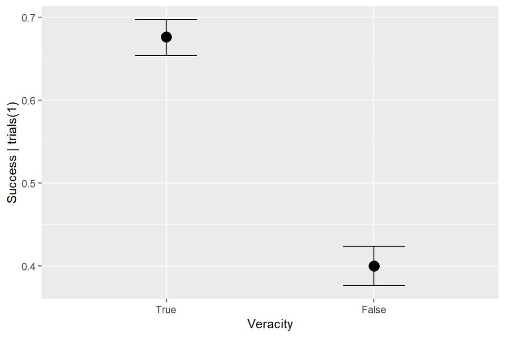

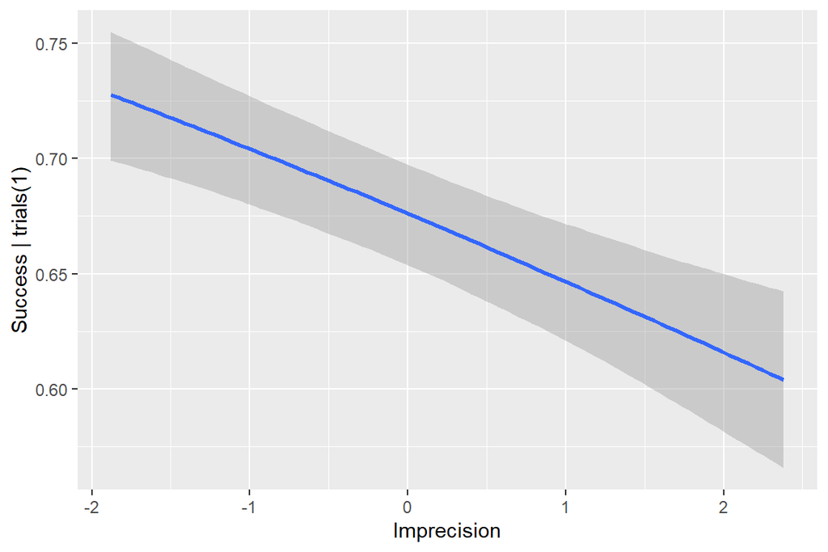

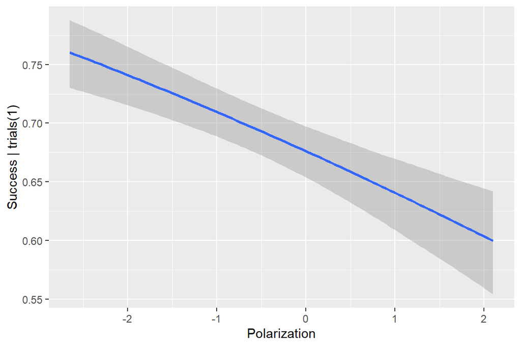

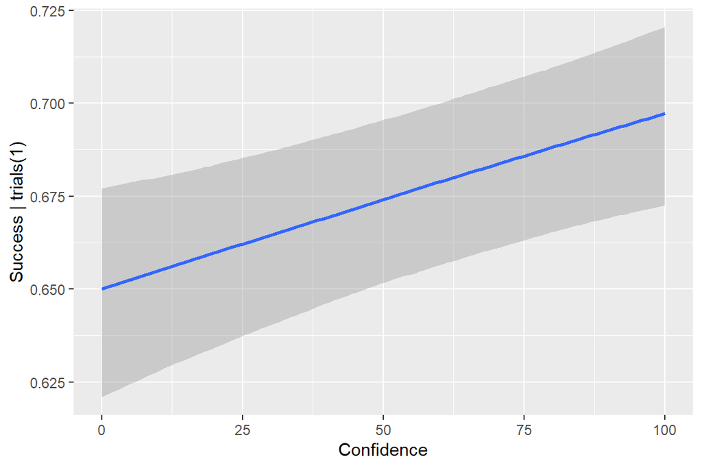

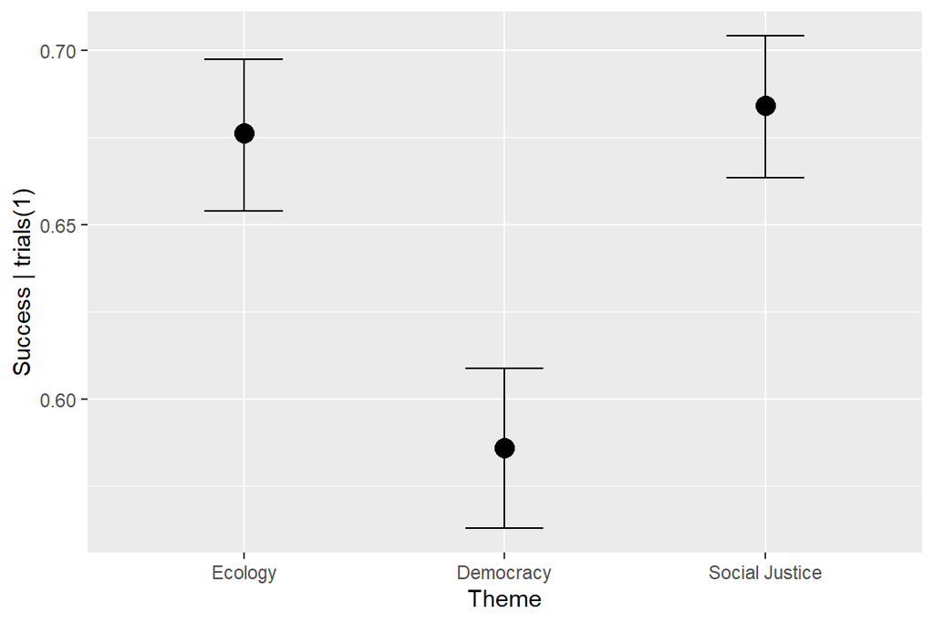

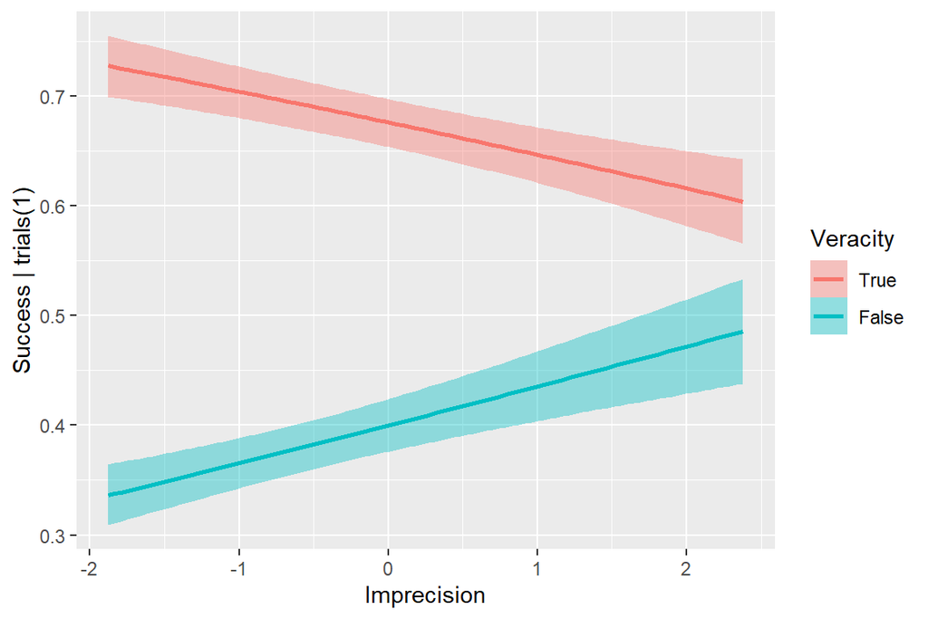

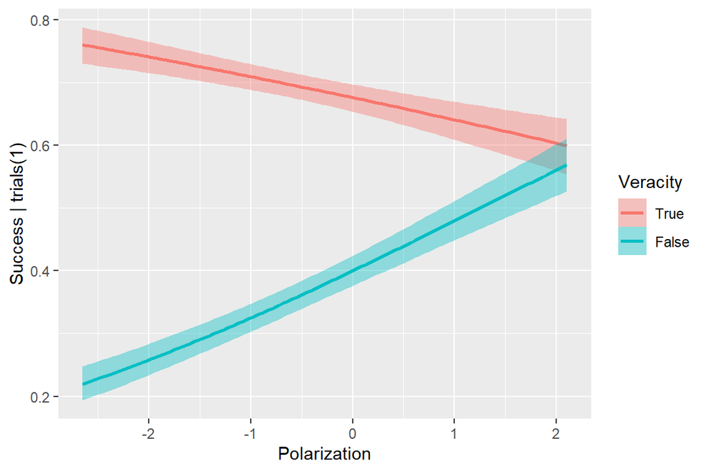

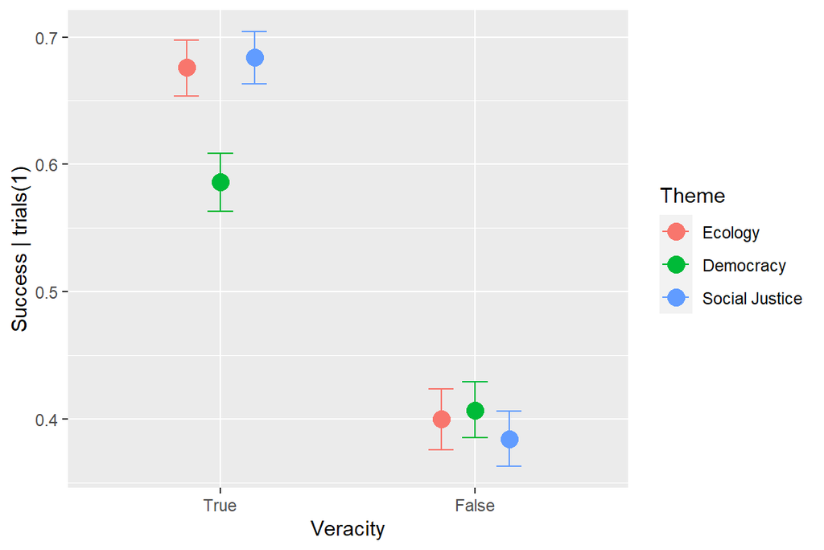

We replot the interaction plot with better suiting colors:

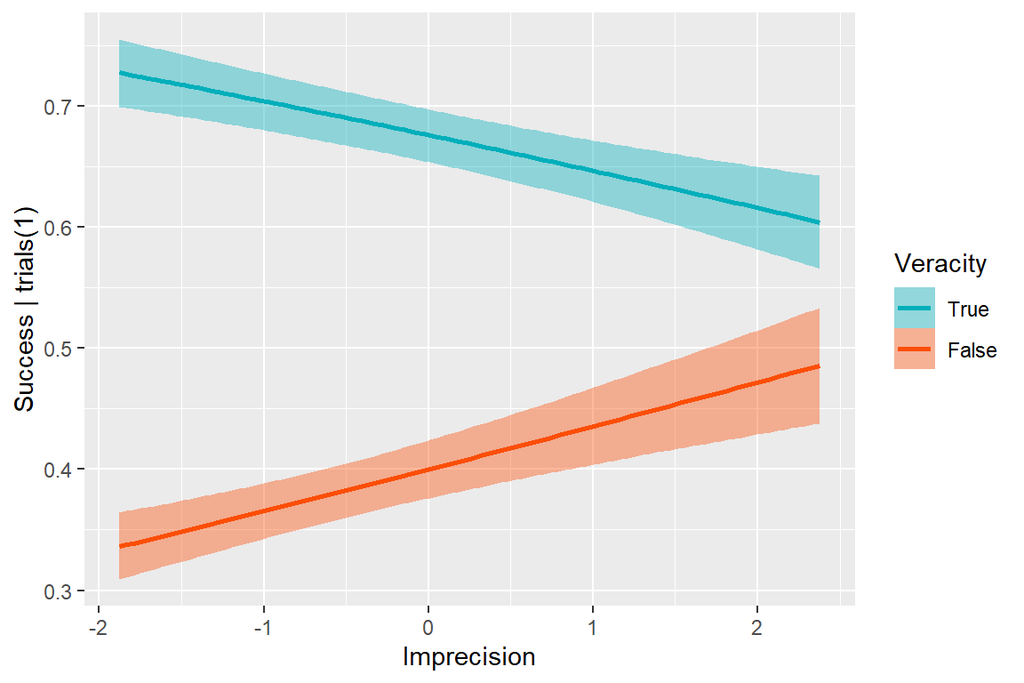

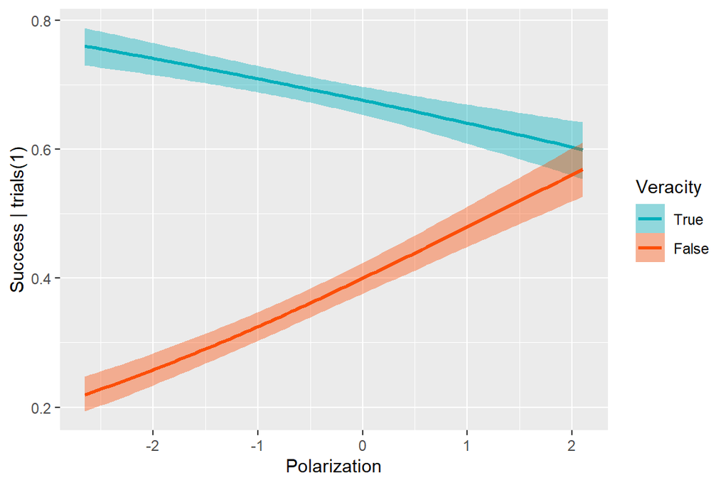

# Winning model: Prior priors

The priors of the winning model are distributed around p = 0.5:

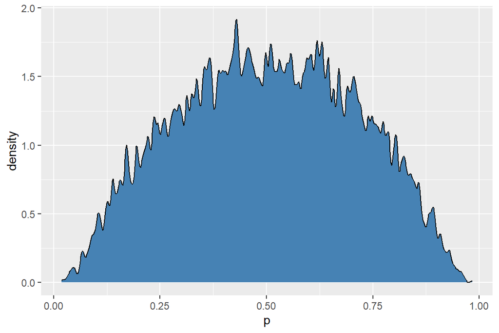

# Winning model: Posterior priors

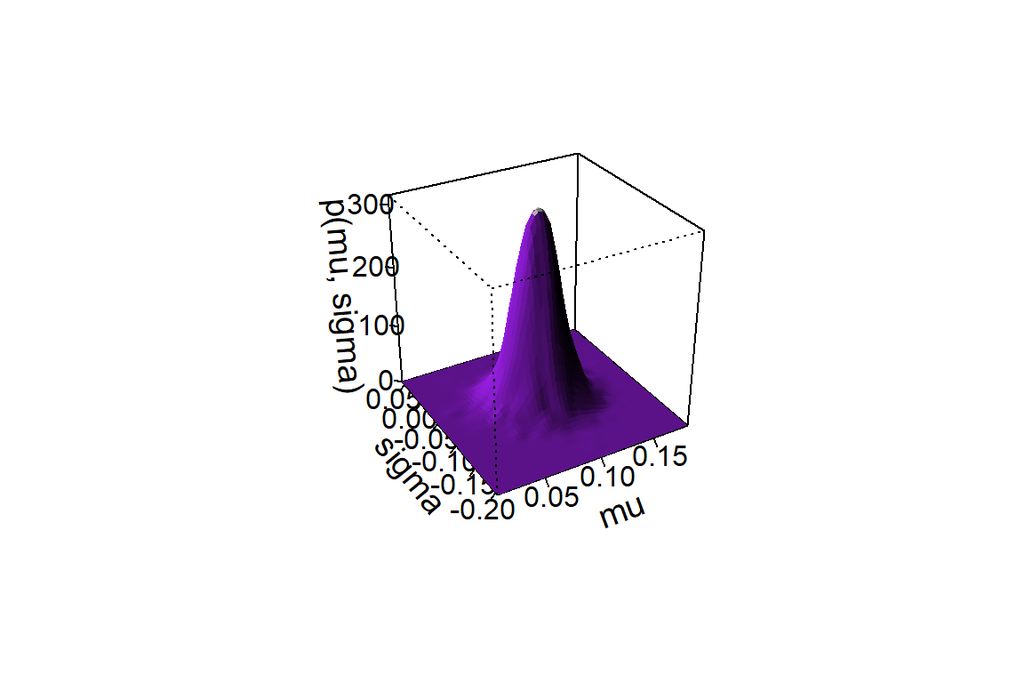

# Winning model: Diagnostics

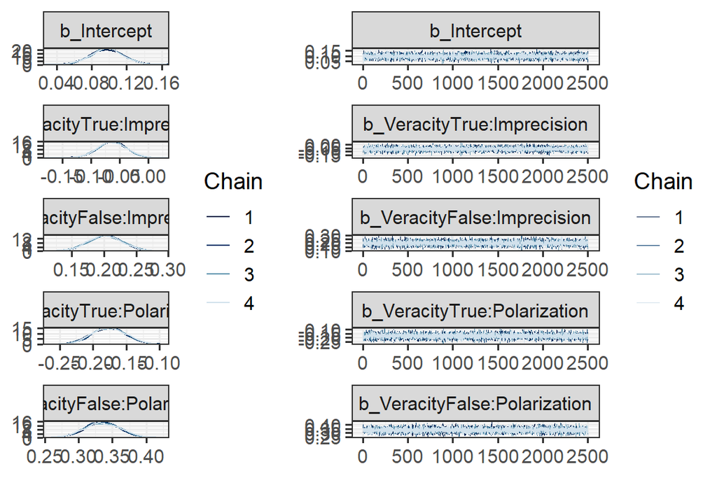

Moreover, the posterior probabilities closely map *y*, the observed data:

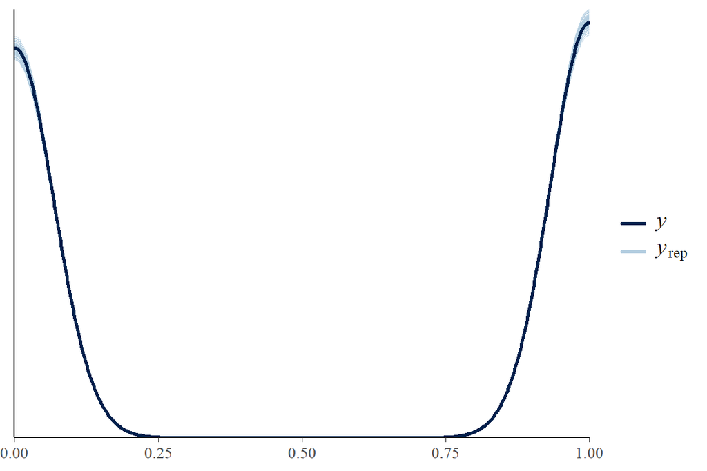

We check the posterior samples, by looking at the Autocorrelation for each parameter. Positive autocorrelation means the chain tends to stay in the same area between iterations. Ideally, we want it to drop quickly to zero with increasing lag.

The posterior samples for False news and True news look uncorrelated after two lags on the graph:

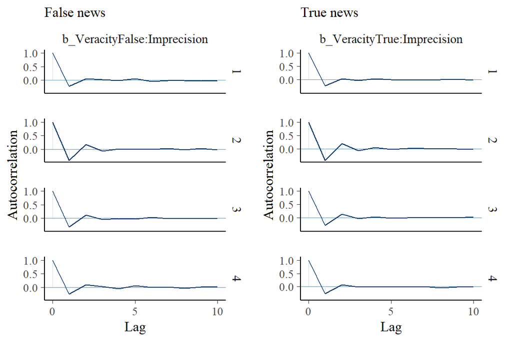